# Handling missing values and Outliers

## Loading the weather-data that is semi wrangled

Previously I wrangled a dataset that contained weather data. With this presentation I plan to check for outliers, look for missing value and explore the different ways of dealing with NA values and experiment with some basic functional programming and filtering time-series data.

```r
library(tidyverse)
library(DataExplorer)
weather_data_pivot_tbl <-  readr::read_rds('weather_data_pivoted.rds')
glimpse(weather_data_pivot_tbl)
```

```
## Observations: 366
## Variables: 23
## $ date                      <chr> "2014/12/1", "2014/12/2", "2014/12/3", "2...
## $ Events                    <chr> "Rain", "Rain-Snow", "Rain", "", "Rain", ...
## $ Max.TemperatureF          <dbl> 64, 42, 51, 43, 42, 45, 38, 29, 49, 48, 3...
## $ Mean.TemperatureF         <dbl> 52, 38, 44, 37, 34, 42, 30, 24, 39, 43, 3...
## $ Min.TemperatureF          <dbl> 39, 33, 37, 30, 26, 38, 21, 18, 29, 38, 3...
## $ Max.Dew.PointF            <dbl> 46, 40, 49, 24, 37, 45, 36, 28, 49, 45, 3...
## $ MeanDew.PointF            <dbl> 40, 27, 42, 21, 25, 40, 20, 16, 41, 39, 3...
## $ Min.DewpointF             <dbl> 26, 17, 24, 13, 12, 36, -3, 3, 28, 37, 27...
## $ Max.Humidity              <dbl> 74, 92, 100, 69, 85, 100, 92, 92, 100, 10...
## $ Mean.Humidity             <dbl> 63, 72, 79, 54, 66, 93, 61, 70, 93, 95, 8...
## $ Min.Humidity              <dbl> 52, 51, 57, 39, 47, 85, 29, 47, 86, 89, 8...
## $ Max.Sea.Level.PressureIn  <dbl> 30.45, 30.71, 30.40, 30.56, 30.68, 30.42,...
## $ Mean.Sea.Level.PressureIn <dbl> 30.13, 30.59, 30.07, 30.33, 30.59, 30.24,...
## $ Min.Sea.Level.PressureIn  <dbl> 30.01, 30.40, 29.87, 30.09, 30.45, 30.16,...
## $ Max.VisibilityMiles       <dbl> 10, 10, 10, 10, 10, 10, 10, 10, 10, 10, 1...
## $ Mean.VisibilityMiles      <dbl> 10, 8, 5, 10, 10, 4, 10, 8, 2, 3, 7, 10, ...
## $ Min.VisibilityMiles       <dbl> 10, 2, 1, 10, 5, 0, 5, 2, 1, 1, 1, 7, 10,...
## $ Max.Wind.SpeedMPH         <dbl> 22, 24, 29, 25, 22, 22, 25, 21, 38, 23, 2...
## $ Mean.Wind.SpeedMPH        <dbl> 13, 15, 12, 12, 10, 8, 15, 13, 20, 13, 13...
## $ Max.Gust.SpeedMPH         <dbl> 29, 29, 38, 33, 26, 25, 32, 28, 52, 29, 2...
## $ PrecipitationIn           <dbl> 0.01, 0.10, 0.44, 0.00, 0.11, 1.09, 0.13,...
## $ CloudCover                <dbl> 6, 7, 8, 3, 5, 8, 6, 8, 8, 8, 8, 7, 5, 4,...
## $ WindDirDegrees            <dbl> 268, 62, 254, 292, 61, 313, 350, 354, 38,...
```

## Type Conversions

The Events column contains data that can be categorised into different classes. Such as Rain day, Rain Snow etc.

- I’ll replace the blank rows with the text “None”
- I’ll start by converting this column to a factor.
- I’ll convert the date column to from character type to a date type

Replace the blanks in the Events column with ‘None’

```r
weather_data_pivot_tbl[weather_data_pivot_tbl$Events == '',"Events"] <- "None"
weather_data_pivot_tbl$Events <- as_factor(weather_data_pivot_tbl$Events)
weather_data_pivot_tbl$date   <- lubridate::as_date(weather_data_pivot_tbl$date)
glimpse(weather_data_pivot_tbl)
```

```
## Observations: 366
## Variables: 23
## $ date                      <date> 2014-12-01, 2014-12-02, 2014-12-03, 2014...
## $ Events                    <fct> Rain, Rain-Snow, Rain, None, Rain, Rain, ...
## $ Max.TemperatureF          <dbl> 64, 42, 51, 43, 42, 45, 38, 29, 49, 48, 3...
## $ Mean.TemperatureF         <dbl> 52, 38, 44, 37, 34, 42, 30, 24, 39, 43, 3...
## $ Min.TemperatureF          <dbl> 39, 33, 37, 30, 26, 38, 21, 18, 29, 38, 3...
## $ Max.Dew.PointF            <dbl> 46, 40, 49, 24, 37, 45, 36, 28, 49, 45, 3...
## $ MeanDew.PointF            <dbl> 40, 27, 42, 21, 25, 40, 20, 16, 41, 39, 3...
## $ Min.DewpointF             <dbl> 26, 17, 24, 13, 12, 36, -3, 3, 28, 37, 27...
## $ Max.Humidity              <dbl> 74, 92, 100, 69, 85, 100, 92, 92, 100, 10...
## $ Mean.Humidity             <dbl> 63, 72, 79, 54, 66, 93, 61, 70, 93, 95, 8...
## $ Min.Humidity              <dbl> 52, 51, 57, 39, 47, 85, 29, 47, 86, 89, 8...
## $ Max.Sea.Level.PressureIn  <dbl> 30.45, 30.71, 30.40, 30.56, 30.68, 30.42,...
## $ Mean.Sea.Level.PressureIn <dbl> 30.13, 30.59, 30.07, 30.33, 30.59, 30.24,...
## $ Min.Sea.Level.PressureIn  <dbl> 30.01, 30.40, 29.87, 30.09, 30.45, 30.16,...
## $ Max.VisibilityMiles       <dbl> 10, 10, 10, 10, 10, 10, 10, 10, 10, 10, 1...
## $ Mean.VisibilityMiles      <dbl> 10, 8, 5, 10, 10, 4, 10, 8, 2, 3, 7, 10, ...
## $ Min.VisibilityMiles       <dbl> 10, 2, 1, 10, 5, 0, 5, 2, 1, 1, 1, 7, 10,...
## $ Max.Wind.SpeedMPH         <dbl> 22, 24, 29, 25, 22, 22, 25, 21, 38, 23, 2...
## $ Mean.Wind.SpeedMPH        <dbl> 13, 15, 12, 12, 10, 8, 15, 13, 20, 13, 13...
## $ Max.Gust.SpeedMPH         <dbl> 29, 29, 38, 33, 26, 25, 32, 28, 52, 29, 2...
## $ PrecipitationIn           <dbl> 0.01, 0.10, 0.44, 0.00, 0.11, 1.09, 0.13,...
## $ CloudCover                <dbl> 6, 7, 8, 3, 5, 8, 6, 8, 8, 8, 8, 7, 5, 4,...
## $ WindDirDegrees            <dbl> 268, 62, 254, 292, 61, 313, 350, 354, 38,...
```

Use the summary() function to get a good feel for the distribution of data within the dataset. This is a very handy way to detect outliers and missing values

```r
summary(weather_data_pivot_tbl)
```

```
##       date                  Events    Max.TemperatureF Mean.TemperatureF
##  Min.   :2014-12-01   None     :201   Min.   :18.00    Min.   : 8.00
##  1st Qu.:2015-03-02   Rain     : 90   1st Qu.:42.00    1st Qu.:36.25
##  Median :2015-06-01   Snow     : 31   Median :60.00    Median :53.50
##  Mean   :2015-06-01   Rain-Snow: 10   Mean   :58.93    Mean   :51.40
##  3rd Qu.:2015-08-31   Fog-Rain :  8   3rd Qu.:76.00    3rd Qu.:68.00
##  Max.   :2015-12-01   Fog-Snow :  7   Max.   :96.00    Max.   :84.00
##                       (Other)  : 19
##  Min.TemperatureF Max.Dew.PointF  MeanDew.PointF   Min.DewpointF
##  Min.   :-3.00    Min.   :-6.00   Min.   :-11.00   Min.   :-18.00
##  1st Qu.:30.00    1st Qu.:32.00   1st Qu.: 24.00   1st Qu.: 16.25
##  Median :46.00    Median :47.50   Median : 41.00   Median : 35.00
##  Mean   :43.33    Mean   :45.48   Mean   : 38.96   Mean   : 32.25
##  3rd Qu.:60.00    3rd Qu.:61.00   3rd Qu.: 56.00   3rd Qu.: 51.00
##  Max.   :74.00    Max.   :75.00   Max.   : 71.00   Max.   : 68.00
##
##   Max.Humidity     Mean.Humidity    Min.Humidity   Max.Sea.Level.PressureIn
##  Min.   :  39.00   Min.   :28.00   Min.   :16.00   Min.   :29.58
##  1st Qu.:  73.25   1st Qu.:56.00   1st Qu.:35.00   1st Qu.:30.00
##  Median :  86.00   Median :66.00   Median :46.00   Median :30.14
##  Mean   :  85.69   Mean   :66.02   Mean   :48.31   Mean   :30.16
##  3rd Qu.:  93.00   3rd Qu.:76.75   3rd Qu.:60.00   3rd Qu.:30.31
##  Max.   :1000.00   Max.   :98.00   Max.   :96.00   Max.   :30.88
##
##  Mean.Sea.Level.PressureIn Min.Sea.Level.PressureIn Max.VisibilityMiles
##  Min.   :29.49             Min.   :29.16            Min.   : 2.000
##  1st Qu.:29.87             1st Qu.:29.76            1st Qu.:10.000
##  Median :30.03             Median :29.94            Median :10.000
##  Mean   :30.04             Mean   :29.93            Mean   : 9.907
##  3rd Qu.:30.19             3rd Qu.:30.09            3rd Qu.:10.000
##  Max.   :30.77             Max.   :30.64            Max.   :10.000
##
##  Mean.VisibilityMiles Min.VisibilityMiles Max.Wind.SpeedMPH Mean.Wind.SpeedMPH
##  Min.   :-1.000       Min.   : 0.000      Min.   : 8.00     Min.   : 4.00
##  1st Qu.: 8.000       1st Qu.: 2.000      1st Qu.:16.00     1st Qu.: 8.00
##  Median :10.000       Median :10.000      Median :20.00     Median :10.00
##  Mean   : 8.861       Mean   : 6.716      Mean   :20.62     Mean   :10.68
##  3rd Qu.:10.000       3rd Qu.:10.000      3rd Qu.:24.00     3rd Qu.:13.00
##  Max.   :10.000       Max.   :10.000      Max.   :38.00     Max.   :22.00
##
##  Max.Gust.SpeedMPH PrecipitationIn    CloudCover    WindDirDegrees
##  Min.   : 0.00     Min.   :0.0000   Min.   :0.000   Min.   :  1.0
##  1st Qu.:21.00     1st Qu.:0.0000   1st Qu.:3.000   1st Qu.:113.0
##  Median :25.50     Median :0.0000   Median :5.000   Median :222.0
##  Mean   :26.99     Mean   :0.1173   Mean   :4.708   Mean   :200.1
##  3rd Qu.:31.25     3rd Qu.:0.0700   3rd Qu.:7.000   3rd Qu.:275.0
##  Max.   :94.00     Max.   :2.9000   Max.   :8.000   Max.   :360.0
##  NA's   :6         NA's   :49
```

## Screening and handling outliers

There seems to be obvious outliers in the Mean.VisibilityMiles column and the Max.Humidity column.

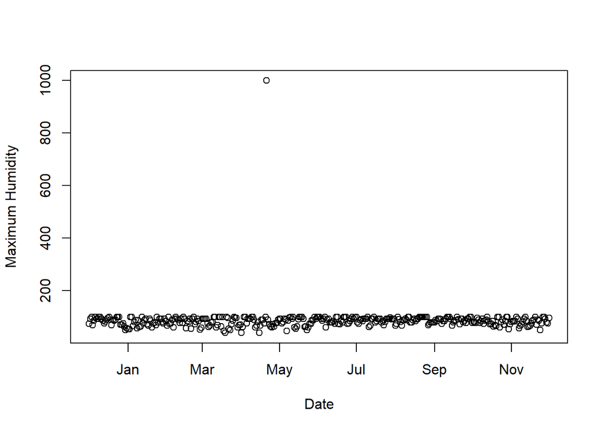

```r
plot(weather_data_pivot_tbl$date, weather_data_pivot_tbl$Max.Humidity,
     ylab = 'Maximum Humidity',
     xlab ='Date'
        )
```

Whatever the cause, this is clearly an invalid data point and needs to be fixed. I’m assuming that it is out by a factor of 10 and dropping a zero should do the trick.

To quickly find the row number of this error, the which.max() from the base package is very handy

```r
weather_data_pivot_tbl$Max.Humidity %>% which.max()
```

```
## [1] 142
```

```r
# the row number is 142 and can be quickly navigated to using dplyr's slice function
weather_data_pivot_tbl %>% slice(142) %>% glimpse()
```

```
## Observations: 1
## Variables: 23
## $ date                      <date> 2015-04-21
## $ Events                    <fct> Fog-Rain-Thunderstorm
## $ Max.TemperatureF          <dbl> 65
## $ Mean.TemperatureF         <dbl> 56
## $ Min.TemperatureF          <dbl> 46
## $ Max.Dew.PointF            <dbl> 57
## $ MeanDew.PointF            <dbl> 49
## $ Min.DewpointF             <dbl> 36
## $ Max.Humidity              <dbl> 1000
## $ Mean.Humidity             <dbl> 71
## $ Min.Humidity              <dbl> 42
## $ Max.Sea.Level.PressureIn  <dbl> 29.75
## $ Mean.Sea.Level.PressureIn <dbl> 29.6
## $ Min.Sea.Level.PressureIn  <dbl> 29.53
## $ Max.VisibilityMiles       <dbl> 10
## $ Mean.VisibilityMiles      <dbl> 5
## $ Min.VisibilityMiles       <dbl> 0
## $ Max.Wind.SpeedMPH         <dbl> 20
## $ Mean.Wind.SpeedMPH        <dbl> 10
## $ Max.Gust.SpeedMPH         <dbl> 94
## $ PrecipitationIn           <dbl> 0.54
## $ CloudCover                <dbl> 6
## $ WindDirDegrees            <dbl> 184
```

```r
# Let's knock off a zero from 1000 and replace it with 100
weather_data_pivot_tbl$Max.Humidity[142] <- 100
```

## Further (not so obvious) errors

```r
min <-  which.min(weather_data_pivot_tbl$Mean.VisibilityMiles)
weather_data_pivot_tbl$Mean.VisibilityMiles[min] <- 10
```

## Handling NA Values

One of the most common problems when working with a dataset is missing values and can be a cause of great trouble that requires careful thought. Recall the 3 types of missing data.

1. Missing completely at random (no relationship between missing data and cirumstances)
2. Missing at random (Circumstances cause some data to be missing)
3. Missing not at random (Cirumstances cause data to be missing, but value that is missing is related to the reason that data is missing )

## Adressing the missing values

Fixing NA values require subject matter expertise and with this data set I chose to replace NA’s by imputation. I’ll replace them with the median.

I chose to replace them with the median because:

- The mean is sensitive to outliers
- The median is robust to outliers - not as heavily impacted by skewed data as the mean.

## Let’s get the percentage-wise NA’s per column relative to the rest of the data set with three different methods

- summarise_all
- map()
- plot_missing()

### Using `summarise_all()`

```r
weather_data_pivot_tbl %>% summarise_all(~ is.na(.) %>% sum()/length(.)*100) %>% glimpse()
```

```
## Observations: 1
## Variables: 23
## $ date                      <dbl> 0
## $ Events                    <dbl> 0
## $ Max.TemperatureF          <dbl> 0
## $ Mean.TemperatureF         <dbl> 0
## $ Min.TemperatureF          <dbl> 0
## $ Max.Dew.PointF            <dbl> 0
## $ MeanDew.PointF            <dbl> 0
## $ Min.DewpointF             <dbl> 0
## $ Max.Humidity              <dbl> 0
## $ Mean.Humidity             <dbl> 0
## $ Min.Humidity              <dbl> 0
## $ Max.Sea.Level.PressureIn  <dbl> 0
## $ Mean.Sea.Level.PressureIn <dbl> 0
## $ Min.Sea.Level.PressureIn  <dbl> 0
## $ Max.VisibilityMiles       <dbl> 0
## $ Mean.VisibilityMiles      <dbl> 0
## $ Min.VisibilityMiles       <dbl> 0
## $ Max.Wind.SpeedMPH         <dbl> 0
## $ Mean.Wind.SpeedMPH        <dbl> 0
## $ Max.Gust.SpeedMPH         <dbl> 1.639344
## $ PrecipitationIn           <dbl> 13.38798
## $ CloudCover                <dbl> 0
## $ WindDirDegrees            <dbl> 0
```

### Using `purrr::map_df()`

```r
# Method 2:

weather_data_pivot_tbl %>%
  map_df(~is.na(.) %>% sum()/length(.)*100) %>%
  gather() %>%
  filter(value >0 )
```

| key | value |
| --- | --- |
| Max.Gust.SpeedMPH | 1.639344 |
| PrecipitationIn | 13.387978 |

### Using `DataExplorer:: plot_missing()`

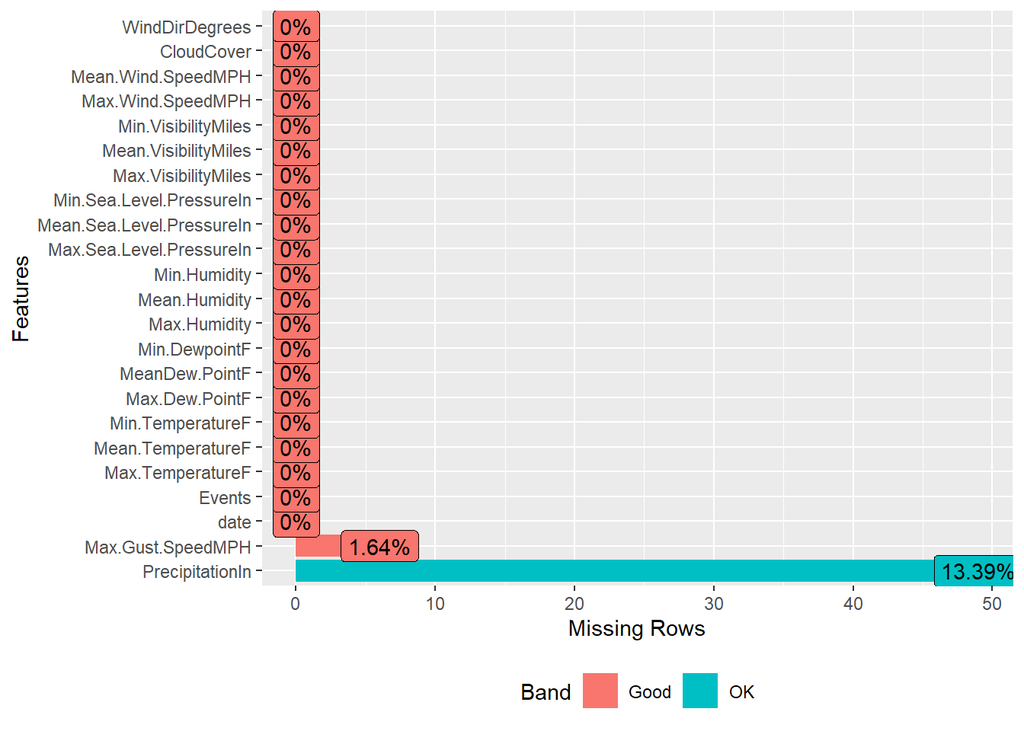

```r
# Method3 :
weather_data_pivot_tbl %>% plot_missing()
```

## Replacing values programmatically

The expression reads as follows: If the column is of numeric type, Scan them for NA’s and if you find them, replace it with the median value of that column, otherwise leave the value as it is.

```r
(weather_data_pivot_tbl2 <-  weather_data_pivot_tbl %>%
     mutate_if(is.numeric, ~ if_else(condition = is.na(.),
                                    true       = median(.,na.rm = TRUE),
                                    false      = .))
 )
```

| date | Events | Max.TemperatureF | Mean.TemperatureF | Min.TemperatureF | Max.Dew.PointF | MeanDew.PointF | Min.DewpointF | Max.Humidity | Mean.Humidity | Min.Humidity | Max.Sea.Level.PressureIn | Mean.Sea.Level.PressureIn | Min.Sea.Level.PressureIn | Max.VisibilityMiles | Mean.VisibilityMiles | Min.VisibilityMiles | Max.Wind.SpeedMPH | Mean.Wind.SpeedMPH | Max.Gust.SpeedMPH | PrecipitationIn | CloudCover | WindDirDegrees |
| --- | --- | --- | --- | --- | --- | --- | --- | --- | --- | --- | --- | --- | --- | --- | --- | --- | --- | --- | --- | --- | --- | --- |
| 2014-12-01 | Rain | 64 | 52 | 39 | 46 | 40 | 26 | 74 | 63 | 52 | 30.45 | 30.13 | 30.01 | 10 | 10 | 10 | 22 | 13 | 29.0 | 0.01 | 6 | 268 |
| 2014-12-02 | Rain-Snow | 42 | 38 | 33 | 40 | 27 | 17 | 92 | 72 | 51 | 30.71 | 30.59 | 30.40 | 10 | 8 | 2 | 24 | 15 | 29.0 | 0.10 | 7 | 62 |
| 2014-12-03 | Rain | 51 | 44 | 37 | 49 | 42 | 24 | 100 | 79 | 57 | 30.40 | 30.07 | 29.87 | 10 | 5 | 1 | 29 | 12 | 38.0 | 0.44 | 8 | 254 |
| 2014-12-04 | None | 43 | 37 | 30 | 24 | 21 | 13 | 69 | 54 | 39 | 30.56 | 30.33 | 30.09 | 10 | 10 | 10 | 25 | 12 | 33.0 | 0.00 | 3 | 292 |
| 2014-12-05 | Rain | 42 | 34 | 26 | 37 | 25 | 12 | 85 | 66 | 47 | 30.68 | 30.59 | 30.45 | 10 | 10 | 5 | 22 | 10 | 26.0 | 0.11 | 5 | 61 |
| 2014-12-06 | Rain | 45 | 42 | 38 | 45 | 40 | 36 | 100 | 93 | 85 | 30.42 | 30.24 | 30.16 | 10 | 4 | 0 | 22 | 8 | 25.0 | 1.09 | 8 | 313 |
| 2014-12-07 | Rain | 38 | 30 | 21 | 36 | 20 | -3 | 92 | 61 | 29 | 30.69 | 30.46 | 30.24 | 10 | 10 | 5 | 25 | 15 | 32.0 | 0.13 | 6 | 350 |
| 2014-12-08 | Snow | 29 | 24 | 18 | 28 | 16 | 3 | 92 | 70 | 47 | 30.77 | 30.67 | 30.51 | 10 | 8 | 2 | 21 | 13 | 28.0 | 0.03 | 8 | 354 |
| 2014-12-09 | Rain | 49 | 39 | 29 | 49 | 41 | 28 | 100 | 93 | 86 | 30.51 | 30.04 | 29.49 | 10 | 2 | 1 | 38 | 20 | 52.0 | 2.90 | 8 | 38 |
| 2014-12-10 | Rain | 48 | 43 | 38 | 45 | 39 | 37 | 100 | 95 | 89 | 29.58 | 29.50 | 29.43 | 10 | 3 | 1 | 23 | 13 | 29.0 | 0.28 | 8 | 357 |

[output cut: 356 more lines]

Note that there are still 366 rows. ⬆️

Check for NA values again using the _**`DataExplorer::plot_missing()`**_fucntion ⬇️

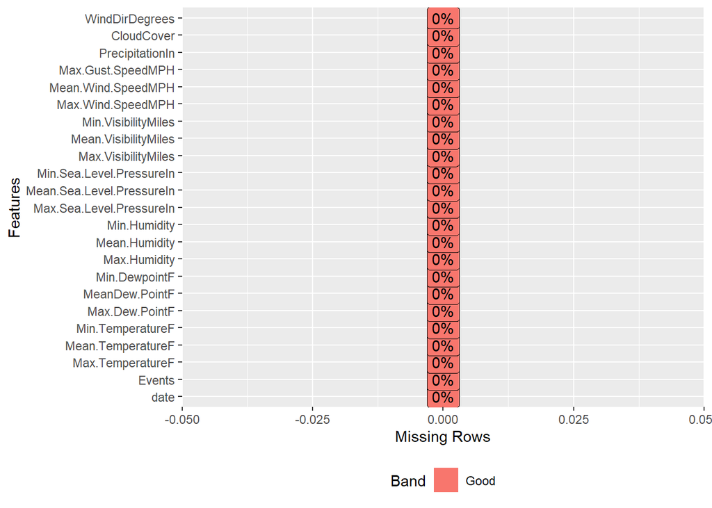

```r
weather_data_pivot_tbl2 %>%
  plot_missing()
```